# Primary Cesarean delivery rates, 2016-2019

2020-09-25

By **Christian McDonald**, Assistant Professor of Practice  
School of Journalism and Media, Moody College of Communication  
University of Texas at Austin

This is an analysis of the Primary Cesarean Delivery Rate, Uncomplicated, as defined by [IQI 33 Primary Cesarean Delivery Rate, Uncomplicated](https://www.qualityindicators.ahrq.gov/Downloads/Modules/IQI/V2020/TechSpecs/IQI_33_Primary_Cesarean_Delivery_Rate_Uncomplicated.pdf) in 2020:

“First-time Cesarean deliveries without a hysterotomy procedure per 1,000 deliveries. Excludes deliveries with complications (abnormal presentation, preterm delivery, fetal death, multiple gestation diagnoses, or breech procedure).”

This analysis has enough results to avoid defining as “per 1,000 deliveries”. I use a simple rate: Primary Cesarean / All uncomplicated deliveries.

## AHRQ definition

This was updated for 2020.

### Numerator

Discharges, among cases meeting the inclusion and exclusion rules for the denominator, with any- listed ICD-10-PCS procedure codes for Cesarean delivery (PRCSECP) and without any-listed ICD- 10-PCS procedure codes for hysterotomy (PRCSE2P).

### Denominator

All deliveries, identified by any-listed ICD-10-CM diagnosis code for outcome of delivery (DELOCMD).

Exclude cases:

- with any-listed ICD-10-CM diagnosis codes for abnormal presentation, preterm, fetal death, or multiple gestation (Appendix A: PRCSECD)
- with any-listed ICD-10-CM diagnosis codes for previous Cesarean delivery (PRVBACD* )
- with an ungroupable DRG (DRG=999)
- with missing gender (SEX=missing), age (AGE=missing), quarter (DQTR=missing), year (YEAR=missing) or principal diagnosis (DX1=missing)

```r
library(tidyverse)
library(janitor)
library(DT)
library(tigris)

# suppresses grouping warning
options(dplyr.summarise.inform = FALSE)
```

## Import of deliveries

I start here with “All deliveries, identified by any-listed ICD-10-CM diagnosis code for outcome of delivery (DELOCMD)”. This was processed in `01-process-loop`.

```r
# set test flag to FALSE to run production data
test_flag <- F

### test data
path_test <- "data-test/ahrq_del_all_loop_test.rds"

### production data
path_prod <- "data-processed/ahrq_del_cleaned.rds"

### import based on flag
if (test_flag == T) del <- read_rds(path_test) else del <- read_rds(path_prod)

del %>% nrow()
```

```
## [1] 1457413
```

## Set up various processing lists

These are lists from the IQI 33 reference used for filtering and such. See 01-process-lists for definitions.

```r
# diagnostic columns
diag_cols <- read_rds("procedures-lists/cols_diag.rds") %>% .$diag

# surgical procedure columns
surg_cols <- read_rds("procedures-lists/cols_surg.rds") %>% .$surg

# appendix a complications list
prcsecd_list <- read_rds("procedures-lists/ahrq_prcsecd.rds") %>% .$prcsecd

# ICD-10-PCS procedure codes for Cesarean delivery
prcsecp_list <- read_rds("procedures-lists/ahrq_prcsecp.rds") %>% .$prcsecp

# Hysterotomy procedure codes: (PRCSE2P)
prcse2p_list <- read_rds("procedures-lists/ahrq_prcse2p.rds") %>% .$prcse2p

# Previous Cesarean delivery diagnosis codes: (PRVBACD)
prvbacd_list <- read_rds("procedures-lists/ahrq_prvbacd.rds") %>% .$prvbacd
```

## Filter deliveries to set denominator

### Filter out complicated deliveries

Start by filtering out rows “with any-listed ICD-10-CM diagnosis codes for abnormal presentation, preterm, fetal death, or multiple gestation (Appendix A: PRCSECD)”.

```r
del_ucmp <- del %>%
  filter_at(
    vars(all_of(diag_cols)),
    all_vars(
      !(. %in% prcsecd_list)
    )
  )

del_ucmp %>% nrow()
```

```
## [1] 1315670
```

### Filter out previous Cesarean deliveries

For this analysis, I need to additionally exclude outcomes “with any-listed ICD-10-CM diagnosis codes for previous Cesarean delivery (PRVBACD)”. This prvbacd_list comes from the AHRQ specification.

```r
del_ucmp <- del_ucmp %>%
  filter_at(
    vars(all_of(diag_cols)),
    all_vars(
      !(. %in% prvbacd_list)
    )
  )

del_ucmp %>% nrow()
```

```
## [1] 1052162
```

### Filter out ungroupable DRG (DRG=999)

There are two Diagnosis Related Groups in the data, `MS_DRG`: Centers for Medicare and Medicaid Services (CMS) Diagnosis Related Group (DRG), as assigned for hospital payment for Medicare beneficiaries; and `APR_DRG`: All Patient Refined (APR) Diagnosis Related Group (DRG) as assigned by 3M APR-DRG Grouper). I filter out records with “999” in either of them.

```r
del_ucmp <- del_ucmp %>%
  filter(
    (APR_DRG != "999"),
    (MS_DRG != "999")
  )

del_ucmp %>% nrow()
```

```
## [1] 1052162
```

This completes our “denominator” set of data. This is saved in `del_ucmp`.

## Code records for numerator

To review: Discharges, among cases meeting the inclusion and exclusion rules for the denominator, with any- listed ICD-10-PCS procedure codes for Cesarean delivery (PRCSECP) and without any-listed ICD- 10-PCS procedure codes for hysterotomy (PRCSE2P).

> NOTE: In 2019, MS-DRG codes for Cesarean delivery changed and that is not reflected in the AHRQ June 2019 specification. See 01-process-lists for more information.

How I handle this:

- Create a column `PRCSECP` that looks through each SURG_PROC column for any value in the prcecp_list.
- Create a column `PRCSE2P` that are hysterotomy cases that looks through each SURG_PROC column for any value in the prcse2p_v2_list.
- Create a primary Cesarean column `PCSEC` based on Cesarean being TRUE and hysterotomy being FALSE.

### Create column PRCSECP for cesarean deliveries

```r
del_ucmp <- del_ucmp %>%
  mutate(
    PRCSECP = case_when(
      PRINC_SURG_PROC_CODE %in% prcsecp_list ~ TRUE,
      OTH_SURG_PROC_CODE_1 %in% prcsecp_list ~ TRUE,
      OTH_SURG_PROC_CODE_2 %in% prcsecp_list ~ TRUE,
      OTH_SURG_PROC_CODE_3 %in% prcsecp_list ~ TRUE,
      OTH_SURG_PROC_CODE_4 %in% prcsecp_list ~ TRUE,
      OTH_SURG_PROC_CODE_5 %in% prcsecp_list ~ TRUE,
      OTH_SURG_PROC_CODE_6 %in% prcsecp_list ~ TRUE,
      OTH_SURG_PROC_CODE_7 %in% prcsecp_list ~ TRUE,
      OTH_SURG_PROC_CODE_8 %in% prcsecp_list ~ TRUE,
      OTH_SURG_PROC_CODE_9 %in% prcsecp_list ~ TRUE,
      OTH_SURG_PROC_CODE_10 %in% prcsecp_list ~ TRUE,
      OTH_SURG_PROC_CODE_11 %in% prcsecp_list ~ TRUE,
      OTH_SURG_PROC_CODE_12 %in% prcsecp_list ~ TRUE,
      OTH_SURG_PROC_CODE_13 %in% prcsecp_list ~ TRUE,
      OTH_SURG_PROC_CODE_14 %in% prcsecp_list ~ TRUE,
      OTH_SURG_PROC_CODE_15 %in% prcsecp_list ~ TRUE,
      OTH_SURG_PROC_CODE_16 %in% prcsecp_list ~ TRUE,
      OTH_SURG_PROC_CODE_17 %in% prcsecp_list ~ TRUE,
      OTH_SURG_PROC_CODE_18 %in% prcsecp_list ~ TRUE,
      OTH_SURG_PROC_CODE_19 %in% prcsecp_list ~ TRUE,
      OTH_SURG_PROC_CODE_20 %in% prcsecp_list ~ TRUE,
      OTH_SURG_PROC_CODE_21 %in% prcsecp_list ~ TRUE,
      OTH_SURG_PROC_CODE_22 %in% prcsecp_list ~ TRUE,
      OTH_SURG_PROC_CODE_23 %in% prcsecp_list ~ TRUE,
      OTH_SURG_PROC_CODE_24 %in% prcsecp_list ~ TRUE,
      TRUE                     ~  FALSE
    )
  )

del_ucmp %>%
  count(PRCSECP)
```

| PRCSECP | n |
| --- | --- |
| FALSE | 861828 |
| TRUE | 190334 |

### Create column based on hysterotomy

… “without any-listed ICD-10-PCS procedure codes for hysterotomy (PRCSE2P).”

It is not surprising that there are zero results here as these are “Abortion of Products of Conception” procedures . Abortions are filtered out in the method used to define deliveries.

I did test the code against unfiltered data to ensure that it does catch the PRCSE2P codes.

> This is a code block that I would like to refactor as a loop through the `surg_cols` list.

```r
#case_when version
del_ucmp <- del_ucmp %>%
  mutate(
    PRCSE2P = case_when(
      PRINC_SURG_PROC_CODE %in% prcse2p_list ~ TRUE,
      OTH_SURG_PROC_CODE_1 %in% prcse2p_list ~ TRUE,
      OTH_SURG_PROC_CODE_2 %in% prcse2p_list ~ TRUE,
      OTH_SURG_PROC_CODE_3 %in% prcse2p_list ~ TRUE,
      OTH_SURG_PROC_CODE_4 %in% prcse2p_list ~ TRUE,
      OTH_SURG_PROC_CODE_5 %in% prcse2p_list ~ TRUE,
      OTH_SURG_PROC_CODE_6 %in% prcse2p_list ~ TRUE,
      OTH_SURG_PROC_CODE_7 %in% prcse2p_list ~ TRUE,
      OTH_SURG_PROC_CODE_8 %in% prcse2p_list ~ TRUE,
      OTH_SURG_PROC_CODE_9 %in% prcse2p_list ~ TRUE,
      OTH_SURG_PROC_CODE_10 %in% prcse2p_list ~ TRUE,
      OTH_SURG_PROC_CODE_11 %in% prcse2p_list ~ TRUE,
      OTH_SURG_PROC_CODE_12 %in% prcse2p_list ~ TRUE,
      OTH_SURG_PROC_CODE_13 %in% prcse2p_list ~ TRUE,
      OTH_SURG_PROC_CODE_14 %in% prcse2p_list ~ TRUE,
      OTH_SURG_PROC_CODE_15 %in% prcse2p_list ~ TRUE,
      OTH_SURG_PROC_CODE_16 %in% prcse2p_list ~ TRUE,
      OTH_SURG_PROC_CODE_17 %in% prcse2p_list ~ TRUE,
      OTH_SURG_PROC_CODE_18 %in% prcse2p_list ~ TRUE,
      OTH_SURG_PROC_CODE_19 %in% prcse2p_list ~ TRUE,
      OTH_SURG_PROC_CODE_20 %in% prcse2p_list ~ TRUE,
      OTH_SURG_PROC_CODE_21 %in% prcse2p_list ~ TRUE,
      OTH_SURG_PROC_CODE_22 %in% prcse2p_list ~ TRUE,
      OTH_SURG_PROC_CODE_23 %in% prcse2p_list ~ TRUE,
      OTH_SURG_PROC_CODE_24 %in% prcse2p_list ~ TRUE,
      TRUE                     ~  FALSE
    )
  )

# peek at results
del_ucmp %>%
  count(PRCSE2P)
```

| PRCSE2P | n |
| --- | --- |
| FALSE | 1052162 |

### Create Primary Cesarean indicator column

Created the `PCSEC` column and set as **TRUE** only if both PRCSE2G is TRUE and PRCSE2P is FALSE.

```r
del_csec <- del_ucmp %>%
  mutate(
    PCSEC = if_else((PRCSECP == T & PRCSE2P == F), T, F)
  )

# peek at data
del_csec %>% count(PCSEC)
```

| PCSEC | n |
| --- | --- |
| FALSE | 861828 |
| TRUE | 190334 |

This completes our “numerator” set of data. This is saved in `del_csec`.

## Create Medicaid indicator column

Creates an `MC` column to indicate **TRUE** if `FIRST_PAYMENT_SRC` value is “MC”, which is the indication for Medicaid Also changes NA values to **FASLE** since those would be unknown.

```r
ahrq_pcsec <- del_csec %>%
  mutate(
    MC = if_else(FIRST_PAYMENT_SRC == "MC", T, F),
    MC = if_else(is.na(MC), F, MC)
  )
```

This completes the processing of the data. `ahrq_pcsec` is our working dataframe.

## Table: Primary Cesarean rate by hospital, combined years

Get Primary Cesarean rate by hospital from all years combined. Hospitals with fewer than 120 deliveries over the data set excluded.

```r
ahrq_pcsec_rate_hosp <- ahrq_pcsec %>%
  group_by(THCIC_ID, PROVIDER_NAME, PCSEC) %>%
  summarize(CNT = n()) %>%
  pivot_wider(names_from = PCSEC, values_from = CNT) %>%
  rename(
    NPCSEC_CNT = "FALSE",
    PCSEC_CNT = "TRUE"
  ) %>%
  mutate(
    TOTAL = NPCSEC_CNT + PCSEC_CNT
  ) %>%
  filter(TOTAL >= 120) %>%
  mutate(
    PCRATE = round_half_up((PCSEC_CNT / TOTAL) * 100,1)
  ) %>%
    arrange(PCRATE %>% desc())

ahrq_pcsec_rate_hosp %>% datatable()
```

|  | THCIC_ID | PROVIDER_NAME | NPCSEC_CNT | PCSEC_CNT | TOTAL | PCRATE |
| --- | --- | --- | --- | --- | --- | --- |
| 1 | 793000 | HCA Houston Healthcare Mainland | 123 | 62 | 185 | 33.5 |
| 2 | 019000 | Valley Regional Medical Center | 3703 | 1724 | 5427 | 31.8 |
| 3 | 301000 | Doctors Hospital-Laredo | 3383 | 1530 | 4913 | 31.1 |
| 4 | 266000 | The Hospitals of Providence Sierra Campus | 1118 | 486 | 1604 | 30.3 |
| 5 | 444001 | CHRISTUS Southeast Texas - St Elizabeth | 3692 | 1541 | 5233 | 29.4 |
| 6 | 074000 | Cuero Regional Hospital | 220 | 81 | 301 | 26.9 |
| 7 | 130000 | The Hospitals of Providence Memorial Campus | 6001 | 2165 | 8166 | 26.5 |
| 8 | 007000 | Womans Hospital-Texas | 21750 | 7663 | 29413 | 26.1 |
| 9 | 314001 | Valley Baptist Medical Center-Brownsville | 3056 | 1071 | 4127 | 26 |
| 10 | 340000 | Medical City Dallas Hospital | 7801 | 2639 | 10440 | 25.3 |

[output cut: 239 more lines]

## Table: Primary Cesarean rates, by hospital and year

Hospitals with fewer than 30 total deliveries within a given year are excluded.

```r
ahrq_pcsec_rate_hosp_yr <- ahrq_pcsec %>%
  group_by(YR, THCIC_ID, PROVIDER_NAME, PCSEC) %>%
  summarize(CNT = n()) %>%
  pivot_wider(names_from = PCSEC, values_from = CNT) %>%
  rename(
    NPCSEC_CNT = "FALSE",
    PCSEC_CNT = "TRUE"
  ) %>%
  mutate(
    TOTAL = NPCSEC_CNT + PCSEC_CNT
  ) %>%
  filter(TOTAL >= 30) %>%
  mutate(
    PCRATE = round_half_up((PCSEC_CNT / TOTAL) * 100,1)
  ) %>%
    arrange(PCRATE %>% desc())

ahrq_pcsec_rate_hosp_yr_table <- ahrq_pcsec_rate_hosp_yr %>%
  arrange(YR) %>%
  select(YR, THCIC_ID, PROVIDER_NAME, PCRATE) %>%
  pivot_wider(names_from = YR, values_from = PCRATE) %>%
  arrange(`2019` %>% desc())

ahrq_pcsec_rate_hosp_yr_table %>% datatable()
```

|  | THCIC_ID | PROVIDER_NAME | 2016 | 2017 | 2018 | 2019 |
| --- | --- | --- | --- | --- | --- | --- |
| 1 | 301000 | Doctors Hospital-Laredo | 30.1 | 34 | 29.4 | 31.1 |
| 2 | 444001 | CHRISTUS Southeast Texas - St Elizabeth | 28.7 | 29.9 | 28.8 | 30.3 |
| 3 | 019000 | Valley Regional Medical Center | 32.5 | 32.4 | 31.9 | 30.1 |
| 4 | 314001 | Valley Baptist Medical Center-Brownsville | 24.2 | 27 | 25 | 28.2 |
| 5 | 464002 | Medical Center-Southeast Texas | 16.8 | 19.8 | 22.4 | 27.2 |
| 6 | 130000 | The Hospitals of Providence Memorial Campus | 26.5 | 26.4 | 26.9 | 26.2 |
| 7 | 007000 | Womans Hospital-Texas | 27.3 | 26 | 25.8 | 25.1 |
| 8 | 429001 | CHRISTUS Spohn Hospital-Beeville | 14.1 | 16.8 | 22.9 | 24.7 |
| 9 | 347000 | Memorial Hermann - Texas Medical Center | 24 | 22.4 | 24.8 | 24.5 |
| 10 | 400000 | Valley Baptist Medical Center | 17.6 | 18.6 | 20.7 | 24.5 |

[output cut: 250 more lines]

## Laredo hospitals

### Primary Cesarean rate combined years, Laredo hospitals

**The TRUE value below is the percentage of deliveries involving all low-risk mothers (without prior Cesareans) that result in a Cesarean delivery.**

The numbers in parenthesis are counts.

```r
ahrq_pcsec %>%
  filter(
     str_detect(PROVIDER_NAME, "Laredo")
  ) %>%
  tabyl(PROVIDER_NAME, PCSEC) %>%
  adorn_percentages() %>%
  adorn_pct_formatting() %>%
  adorn_ns()
```

|  | PROVIDER_NAME | FALSE | TRUE |
| --- | --- | --- | --- |
| 1 | Doctors Hospital-Laredo | 68.9% (3383) | 31.1% (1530) |
| 2 | Laredo Medical Center | 75.7% (6509) | 24.3% (2091) |

### Primary Cesarean rate by year, Laredo hospitals

```r
ahrq_pcsec_rate_hosp_yr_table %>%
  filter(str_detect(PROVIDER_NAME, "Laredo"))
```

| THCIC_ID | PROVIDER_NAME | 2016 | 2017 | 2018 | 2019 |
| --- | --- | --- | --- | --- | --- |
| 301000 | Doctors Hospital-Laredo | 30.1 | 34 | 29.4 | 31.1 |
| 207001 | Laredo Medical Center | 25.5 | 23 | 24.6 | 23.9 |

### Chart: Primary Cesarean Rates by year, Laredo

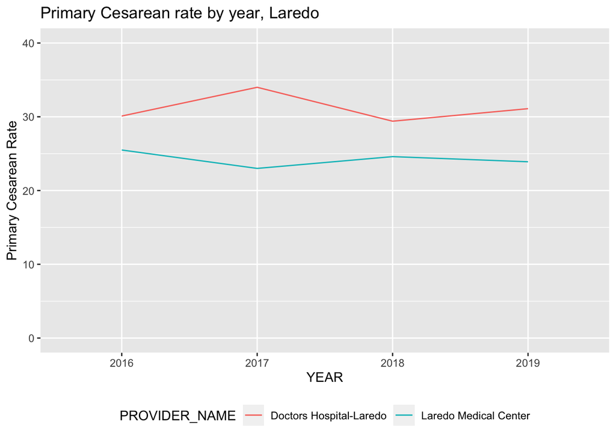

```r
ahrq_pcsec_rate_hosp_yr %>%
  filter(str_detect(PROVIDER_NAME, "Laredo")) %>%
  ggplot(aes(YR, PCRATE)) +
  geom_line(aes(group = PROVIDER_NAME, color = PROVIDER_NAME)) +
  expand_limits(y = c(0,40)) +
  theme(legend.position="bottom", legend.box = "vertical") +
  labs(title = "Primary Cesarean rate by year, Laredo", x = "YEAR", y = "Primary Cesarean Rate")
```

### Chart: Primary Cesarean rates by quarter, Laredo

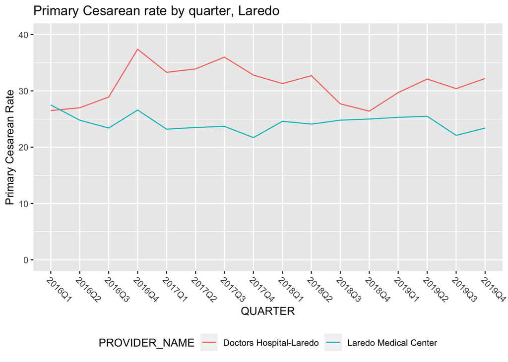

```r
ahrq_pcsec_rate_hosp_qr <- ahrq_pcsec %>%
  group_by(DISCHARGE, PROVIDER_NAME, PCSEC) %>%
  summarize(CNT = n()) %>%
  pivot_wider(names_from = PCSEC, values_from = CNT) %>%
  rename(
    NPCSEC_CNT = "FALSE",
    PCSEC_CNT = "TRUE"
  ) %>%
  mutate(
    TOTAL = NPCSEC_CNT + PCSEC_CNT
  ) %>%
  mutate(
    PCRATE = round_half_up((PCSEC_CNT / TOTAL) * 100,1)
  ) %>%
    arrange(PCRATE %>% desc())

ahrq_pcsec_rate_hosp_qr %>%
  filter(str_detect(PROVIDER_NAME, "Laredo")) %>%
  ggplot(aes(DISCHARGE, PCRATE)) +
  geom_line(aes(group = PROVIDER_NAME, color = PROVIDER_NAME)) +
  expand_limits(y = c(0,40)) +
  theme(legend.position="bottom", legend.box = "vertical", axis.text.x=element_text(angle = -45, hjust = 0)) +
  labs(title = "Primary Cesarean rate by quarter, Laredo", x = "QUARTER", y = "Primary Cesarean Rate")
```

## Table: Considering Medicaid

The questions we wanted to answer here is: What is the percentage of patients on Medicaid that get a primary cesarean? How does that compare to patients not on medicare?

`MEDI_W_PCSEC` is the percentage of Medicaid (as first payment option) patients that get primary cesareans. `NOT_MEDI_W_PCSEC` is the percentage of patients NOT using Medicaid that get primary cesareans. Printed table filters out hospitals with less than 20 Medicaid births.

```r
mc_compare <- ahrq_pcsec %>%
  group_by(THCIC_ID, PROVIDER_NAME) %>%
  summarize(
    MCT = sum(MC == T), # medicaid count
    MCPCT = sum(MC == T & PCSEC == T), # medicaid with primary csection
    MEDI_W_PCSEC = ((MCPCT/MCT) * 100) %>% round_half_up(1),
    NMCT = sum(MC != T), # not medicare count
    NMCPCT = sum(MC != T & PCSEC == T), #not medicaid with primary csection
    NOT_MEDI_W_PCSEC = ((NMCPCT / NMCT) * 100) %>% round_half_up(1),
    PDIFF =  MEDI_W_PCSEC - NOT_MEDI_W_PCSEC
  )

# select fewer cols for easy comparison
mc_compare %>%
  filter(MCT >= 20) %>% # at lest 20 medicaid patients
  select(THCIC_ID, PROVIDER_NAME, MEDI_W_PCSEC, NOT_MEDI_W_PCSEC, PDIFF) %>%
  arrange(PDIFF %>% desc()) %>%
  datatable()
```

|  | THCIC_ID | PROVIDER_NAME | MEDI_W_PCSEC | NOT_MEDI_W_PCSEC | PDIFF |
| --- | --- | --- | --- | --- | --- |
| 1 | 487000 | Memorial Medical Center | 24.1 | 14.6 | 9.5 |
| 2 | 294000 | Hamilton Hospital | 15.6 | 6.7 | 8.9 |
| 3 | 046000 | Faith Community Hospital | 19.6 | 10.8 | 8.8 |
| 4 | 975296 | UT Health East Texas Jacksonville Hospital | 17.3 | 9.3 | 8 |
| 5 | 974390 | HCA Houston Healthcare Pearland | 23.9 | 17.1 | 6.8 |
| 6 | 307000 | Covenant Hospital-Levelland | 13.9 | 9.8 | 4.1 |
| 7 | 216001 | CHRISTUS Spohn Hospital-Kleberg | 15.4 | 11.8 | 3.6 |
| 8 | 654000 | Golden Plains Community Hospital | 21.8 | 18.3 | 3.5 |
| 9 | 975286 | Baylor Scott &amp; White Medical Center Lake Pointe | 21 | 17.7 | 3.3 |
| 10 | 070000 | Goodall - Witcher Hospital | 15.2 | 12.1 | 3.1 |

[output cut: 249 more lines]

### Considering Medicaid, Laredo hospitals

```r
mc_compare %>%
  filter(str_detect(PROVIDER_NAME, "Laredo"))
```

| THCIC_ID | PROVIDER_NAME | MCT | MCPCT | MEDI_W_PCSEC | NMCT | NMCPCT | NOT_MEDI_W_PCSEC | PDIFF |
| --- | --- | --- | --- | --- | --- | --- | --- | --- |
| 207001 | Laredo Medical Center | 6107 | 1408 | 23.1 | 2493 | 683 | 27.4 | -4.3 |
| 301000 | Doctors Hospital-Laredo | 1170 | 349 | 29.8 | 3743 | 1181 | 31.6 | -1.8 |

## Patient County

A look at Primary cesarean by the county of the patient. Note the hospital could be elsewhere.

```r
tx_fips <- fips_codes %>%
  filter(state == "TX") %>%
  select(county_code, county)
# peek
tx_fips %>% head(2)
```

|  | county_code | county |
| --- | --- | --- |
| 1 | 001 | Anderson County |
| 2 | 003 | Andrews County |

### Primary cesarean by county, full data

Currently not filtered for any minimum caseload since it is a 3+ year period.

```r
ahrq_pcsec_rate_county <- ahrq_pcsec %>%
  group_by(PAT_COUNTY, PCSEC) %>%
  summarize(CNT = n()) %>%
  ### join for county names
  left_join(tx_fips, by=c( "PAT_COUNTY" = "county_code")) %>%
  ungroup() %>%
  rename(COUNTY = county) %>%
  pivot_wider(names_from = PCSEC, values_from = CNT) %>%
  rename(
    NPCSEC_CNT = "FALSE",
    PCSEC_CNT = "TRUE"
  ) %>%
  mutate(
    TOTAL = NPCSEC_CNT + PCSEC_CNT
  ) %>%
  ### filter by cases
  # filter(TOTAL >= 10) %>%
  mutate(
    PCRATE = round_half_up((PCSEC_CNT / TOTAL) * 100,1)
  ) %>%
    arrange(PCRATE %>% desc())

ahrq_pcsec_rate_county %>%
  select(-PAT_COUNTY) %>%
    datatable()
```

|  | COUNTY | NPCSEC_CNT | PCSEC_CNT | TOTAL | PCRATE |
| --- | --- | --- | --- | --- | --- |
| 1 | Loving County | 1 | 1 | 2 | 50 |
| 2 | Borden County | 3 | 2 | 5 | 40 |
| 3 | Kent County | 6 | 4 | 10 | 40 |
| 4 | Webb County | 9065 | 3308 | 12373 | 26.7 |
| 5 | Newton County | 191 | 67 | 258 | 26 |
| 6 | Hardin County | 1291 | 450 | 1741 | 25.8 |
| 7 | Goliad County | 133 | 46 | 179 | 25.7 |
| 8 | Orange County | 2029 | 690 | 2719 | 25.4 |
| 9 | Jim Hogg County | 124 | 42 | 166 | 25.3 |
| 10 | Cameron County | 11553 | 3803 | 15356 | 24.8 |

[output cut: 245 more lines]

### Primary cesarean by county, by year

This table excludes records with fewer than 10 cases in a county in a given year, which reduces the number of available counties.

```r
ahrq_pcsec_rate_county_yr <- ahrq_pcsec %>%
  group_by(YR, PAT_COUNTY, PCSEC) %>%
  summarize(CNT = n()) %>%
  ### join for county names
  left_join(tx_fips, by=c( "PAT_COUNTY" = "county_code")) %>%
  ungroup() %>%
  rename(COUNTY = county) %>%
  pivot_wider(names_from = PCSEC, values_from = CNT) %>%
  rename(
    NPCSEC_CNT = "FALSE",
    PCSEC_CNT = "TRUE"
  ) %>%
  mutate(
    TOTAL = NPCSEC_CNT + PCSEC_CNT
  ) %>%
  ### filter by caseload
  filter(TOTAL >= 10) %>%
  mutate(
    PCRATE = round_half_up((PCSEC_CNT / TOTAL) * 100,1)
  ) %>%
    arrange(PCRATE %>% desc())

ahrq_pcsec_rate_county_yr_table <- ahrq_pcsec_rate_county_yr %>%
  arrange(YR) %>%
  select(YR, COUNTY, PCRATE) %>%
  pivot_wider(names_from = YR, values_from = PCRATE) %>%
  arrange(`2019` %>% desc())

ahrq_pcsec_rate_county_yr_table %>%  datatable()
```

|  | COUNTY | 2016 | 2017 | 2018 | 2019 |
| --- | --- | --- | --- | --- | --- |
| 1 | Hall County | 20 | 30.8 | 15.8 | 33.3 |
| 2 | Goliad County | 18.8 | 25.6 | 27.9 | 30.6 |
| 3 | Culberson County | 21.1 | 15.4 | 26.3 | 29.4 |
| 4 | Shackelford County | 10 | 15.8 | 22.2 | 28.6 |
| 5 | Orange County | 23.7 | 23.2 | 26.2 | 28.5 |
| 6 | Newton County | 21.2 | 31.8 | 23.4 | 27.4 |
| 7 | Foard County | 23.1 |  |  | 27.3 |
| 8 | Webb County | 26.6 | 27.2 | 26.7 | 26.4 |
| 9 | Jefferson County | 22.8 | 23.6 | 23.7 | 26.2 |
| 10 | Cameron County | 24.1 | 24.4 | 24.9 | 25.9 |

[output cut: 234 more lines]

## Summaries

### Primary Cesarean rate statewide

This compares all the cases and gives us a percentage of those that are Primary Cesarean births. **The TRUE value is the percentage of deliveries involving all low-risk mothers (without prior Cesareans) that result in a Cesarean delivery.**

```r
ahrq_pcsec %>%
  tabyl(PCSEC) %>%
  rename(count = n) %>%
  adorn_pct_formatting()
```

| PCSEC | count | percent |
| --- | --- | --- |
| FALSE | 861828 | 81.9% |
| TRUE | 190334 | 18.1% |

```r
ahrq_pcsec_rate_tx_summary <- ahrq_pcsec %>%
  group_by(PCSEC) %>%
  summarize(CNT = n()) %>%
  pivot_wider(names_from = PCSEC, values_from = CNT) %>%
  rename(
    NPCSEC_CNT = "FALSE",
    PCSEC_CNT = "TRUE"
  ) %>%
  mutate(
    TOTAL = NPCSEC_CNT + PCSEC_CNT
  ) %>%
  mutate(
   SUMMARY = "TX",
   CATEGORY = "PRIMARY_CESAREAN",
   MEASUREMENT = "RATE",
   VALUE = round_half_up((PCSEC_CNT / TOTAL) * 100,1) # RATE
  ) %>%
  select(SUMMARY, CATEGORY, MEASUREMENT, VALUE)

ahrq_pcsec_rate_tx_summary
```

| SUMMARY | CATEGORY | MEASUREMENT | VALUE |
| --- | --- | --- | --- |
| TX | PRIMARY_CESAREAN | RATE | 18.1 |

### Primary Cesarean rate statewide by year

```r
ahrq_pcsec_rate_tx_yr_summary <- ahrq_pcsec %>%
  group_by(PCSEC, YR) %>%
  summarize(CNT = n()) %>%
  pivot_wider(names_from = PCSEC, values_from = CNT) %>%
  rename(
    NPCSEC_CNT = "FALSE",
    PCSEC_CNT = "TRUE"
  ) %>%
  mutate(
    TOTAL = NPCSEC_CNT + PCSEC_CNT
  ) %>%
  filter(TOTAL >= 30) %>%
  mutate(
   SUMMARY = "TX",
   CATEGORY = "PRIMARY_CESAREAN",
   MEASUREMENT = "RATE",
   VALUE = round_half_up((PCSEC_CNT / TOTAL) * 100,1) # RATE
  ) %>%
  select(YR, SUMMARY, CATEGORY, MEASUREMENT, VALUE)

ahrq_pcsec_rate_tx_yr_summary
```

| YR | SUMMARY | CATEGORY | MEASUREMENT | VALUE |
| --- | --- | --- | --- | --- |
| 2016 | TX | PRIMARY_CESAREAN | RATE | 18.3 |
| 2017 | TX | PRIMARY_CESAREAN | RATE | 18.2 |
| 2018 | TX | PRIMARY_CESAREAN | RATE | 18.0 |
| 2019 | TX | PRIMARY_CESAREAN | RATE | 17.8 |

### Primary Cesarean rate by hospital: Averaged, by year

```r
ahrq_pcsec_rate_hosp_yr_summary <- ahrq_pcsec_rate_hosp_yr %>%
  ungroup() %>%
  group_by(YR) %>%
  summarize(
    SUMMARY = "HOSPITAL",
    CATEGORY = "PRIMARY_CESAREAN",
    MEASUREMENT = "MEAN_OF_RATE",
    # MEDIAN = median(PCRATE),
    VALUE = round_half_up(mean(PCRATE),1) #MEAN
  )

ahrq_pcsec_rate_hosp_yr_summary
```

| YR | SUMMARY | CATEGORY | MEASUREMENT | VALUE |
| --- | --- | --- | --- | --- |
| 2016 | HOSPITAL | PRIMARY_CESAREAN | MEAN_OF_RATE | 17.5 |
| 2017 | HOSPITAL | PRIMARY_CESAREAN | MEAN_OF_RATE | 17.4 |
| 2018 | HOSPITAL | PRIMARY_CESAREAN | MEAN_OF_RATE | 17.4 |
| 2019 | HOSPITAL | PRIMARY_CESAREAN | MEAN_OF_RATE | 17.0 |

## Write files

Writing out aggregate files. Here is a list of CSVs exports:

- ahrq_pcsec_rate_county_yr.csv: Grouped by PAT_COUNTY, COUNTY. Aggregations are NPCSEC_CNT (Count not primary Cesarean), PCSEC_CNT (Count primary Cesarean), TOTAL, PCRATE (Primary Cesarean rate).

And some summary data, including:

- ahrq_pcsec_rate_hosp_yr.rds: Grouped by PROVIDER_NAME and YR. Aggregations are NPCSEC_CNT (Count not primary Cesarean), PCSEC_CNT (Count primary Cesarean), TOTAL, PCRATE (Primary Cesarean rate).

```r
# if (test_flag == F) ahrq_pcsec %>% write_rds("data-processed/ahrq_pcsec.rds")

if (test_flag == F) ahrq_pcsec_rate_tx_yr_summary %>%
  write_rds("data-processed/ahrq_pcsec_rate_tx_yr_summary.rds")

if (test_flag == F) ahrq_pcsec_rate_hosp_yr_summary %>%
  write_rds("data-processed/ahrq_pcsec_rate_hosp_yr_summary.rds")

if (test_flag == F) ahrq_pcsec_rate_hosp_yr %>%
  write_rds("data-processed/ahrq_pcsec_rate_hosp_yr.rds")

if (test_flag == F) ahrq_pcsec_rate_hosp_yr %>%
  arrange(PROVIDER_NAME,YR) %>%
  write_csv("exports/ahrq_pcsec_rate_hosp_yr.csv")

if (test_flag == F) ahrq_pcsec_rate_county_yr %>%
  write_csv("exports/ahrq_pcsec_rate_county_yr.csv")

# A klaxon to indicate the processing is complete
beepr::beep(4)
```